# Homework 1: Regression Model Evaluation

STAT 253

# Learning Goals

- Practice **data wrangling and visualization**, the foundations of any data analysis.
- Practice **building** and **evaluating** *linear regression models*.
- Explore the concepts of variable **scaling** and **transformations**.

# Directions & Policies (READ ME)

## Tips

To make HW go more smoothly, deepen your learning, & maximize happiness:

- *Before* starting HW, **review** the last couple weeks of material.
- Start early! HW isn’t designed to be completed in a single sitting.
- Use Slack to invite others to join you.
  - Just make sure that the work you submit, *including code*, is written **in your own words**.
- WHEN you have questions:
  - Ask questions in the `#help-homework` channel on Slack.
  - Stop by office hours. (Please remember that OH are for *group* discussion and exploring concepts / specific questions, **not** doing HW step by step or checking your answers.)

## Content

HW includes exercises that apply course concepts to novel settings, and open-ended questions that challenge you to **synthesize** and **build upon** course concepts. This is just like a language class! You learn the grammar, vocabulary, and structure needed to express your own ideas (as opposed to memorizing every sentence you might ever want to say). This is challenging *by design* – it encourages you to practice taking academic risks, be comfortable making mistakes, gain confidence outside the classroom setting, and discover more depth in the material.

## Timing & Flexibility

- Deadlines:
  - are posted on Moodle and the course calendar
  - provide common checkpoints such that we can build upon the new knowledge in class (the concepts in this course build on each other!)
  - allow the instructor and preceptors to get feedback to you in a timely manner
  - help us all manage and plan our workloads
- Grace period:
  - late work will be accepted, without any penalty to your grade, if it is submitted within **1 hour** of the deadline
- Extensions:
  - if you are unable to submit your work by the deadline (or within the grace period), please contact your instructor to request an extension; you do not need to provide a reason for your request
  - all STAT 253 students will automatically be granted three 3-day homework extensions to use throughout the semester
  - extensions should be requested **before** the assignment so that instructors and preceptors can plan their grading accordingly
  - except in rare circumstances, we will not be able to accommodate homework being submitted more than 3 days past the deadline (because the concepts in this course build on each other quickly); plan accordingly
- Why are the course policies designed in this way?
  - to provide flexibility and grace to students while ensuring that they stay on track to succeed in this course
  - to provide structure to allow the instructor and preceptors to efficiently give feedback

## Academic Integrity

Review and stick to the academic integrity expectations in the syllabus.

You **may *not*:**

- use any materials from past iterations of STAT 253
- use any online solutions manuals or forums where you post HW related questions
- pass off another person’s work as your own. (You’re encouraged to discuss HW with classmates but all submitted work must be your own, from the words to the code.)

You *may* use ChatGPT or other online resources to help get unstuck. However…

- you **may *not*** copy-and-paste content and pass it off as your own (this doesn’t help you learn!)
- your use of AI should be **cited**; there is space for you at the end of the assignment to do so
- note that AI uses a lot of resources; if you can do something in a more energy-efficient way (eg using pre-existing course materials) please do so!

In general:

- You must be able to defend / explain any content in your homework, if asked. In other words, **all of the work that you submit must be an accurate reflection of YOUR understanding.**
- You must **use the tools, code, techniques, etc. from this course**. (Be particularly careful here if using ChatGPT or other online resources that were not provided by your instructor.)

## Feedback

Within one week of the assignment deadline, preceptors and your instructor will provide qualitative feedback on most exercises and an overall score of PASS, ATTEMPT, or UNABLE TO ASSESS.

You will make mistakes and your HW won’t be perfect. That’s ok! This is an opportunity to *practice* and *synthesize* material and that will involve making mistakes. To align with our learning goals, we’re looking for students to “pass” the HW.

To **PASS**, you must meet the following goals:

1. Your HW is handed in on time, or within the grace period.
2. Your work is reproducible and presented professionally. Specifically:
   - Use the provided QMD template.
     - Update the author (your name).
     - You can make necessary modifications to this template (eg: add answers, R chunks), but cannot make any deletions or changes to the structure.
   - Include all RStudio code and output that’s relevant to the HW exercises.
   - Omit any RStudio code that’s *not* relevant to the HW exercises.
   - Submit your *rendered HTML* (not QMD) file to the correct HW link on Moodle.
3. Your submission demonstrates a good faith effort to complete all, or almost all, exercises.
4. Your answers to *most* (but not necessarily all!) exercises are either “correct” or “almost correct”.
   - The following are required to earn a “correct” score:
     - Answer is correct and complete.
     - Answer is supported with appropriate evidence (e.g. R code and output).
     - Discussions are based in the context of the exercise, not general definitions.
     - R code is well-formatted and organized.
   - The following are required to earn a “almost correct” score:
     - There are some mistakes, but you got more than ~75% correct.
     - You demonstrated an earnest attempt at each part of the exercise.

# Exercises

## Data Context

A meteorologist in Australia wants to improve their forecasts for the cities of Hobart, Adelaide, Canberra, Brisbane, Melbourne, and Sydney. They go on the news at 9am and hire you to predict what the temperature will be at 3pm. They provide you with the `weatherAUS` data set from the `rattle` package which contains daily weather information from multiple locations throughout Australia:

```r
library(rattle)
data(weatherAUS)
dim(weatherAUS)
## [1] 208495     24
```

You can access a codebook by typing the following in your *console* (don’t put this in your QMD):

```r
?weatherAUS
```

## Exercise 1

**Getting to know the data: data wrangling and visualization**

Before building any models, let’s get to know the data itself using our **tidyverse** tools: `ggplot()` and the `dplyr` verbs `filter()`, `arrange()`, `mutate()`, `select()`, `summarize()`, `group_by()`.

If you need a refresher: the appendix of the course website includes an *R Resources* guide. I recommend the “Six Main Verbs” section of Comp/Stat 112.

### Part a

Create a smaller “`weather`” dataset with the following features:

- includes data on only the 6 locations for which the meteorologist provides forecasts
- converts `Temp9am` and `Temp3pm` to Fahrenheit, from Celsius
- only includes `Temp3pm` and information that would be available at 9am: `Location`, `WindSpeed9am`, `Humidity9am`, `Pressure9am`, `Temp9am`

**Hint**

You should work out this exercise in pieces, then use this code as a final template:

```r
___ <- ___ %>%
  ___(Location %in% c(___)) %>%
  ___(Temp9am = ___, Temp3pm = ___) %>%
  ___(Temp3pm, Location, WindSpeed9am, Humidity9am, Pressure9am,
      Temp9am)
```

**Demonstrate that your work produces the following output:**

```r
dim(weather)
## [1] 26828     6
head(weather, 2)
## # A tibble: 2 × 6
##   Temp3pm Location WindSpeed9am Humidity9am Pressure9am Temp9am
##     <dbl> <chr>           <dbl>       <int>       <dbl>   <dbl>
## 1    69.6 Sydney             17          92       1018.    69.3
## 2    76.6 Sydney              9          83       1018.    72.3
```

### Part b

Display data for the 3 days with the hottest 3pm temperatures.

### Part c

Calculate the mean 3pm temperature at each of the six locations. Since there are some missing values in the data (NA), use `mean(___, na.rm = TRUE)` to remove (`rm`) these `na` values from the calculation.

### Part d

Reproduce the 2 visualizations below.

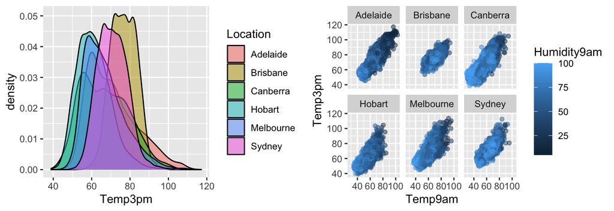

### Part e

**REVIEW:** Write a 1-2 sentence summary of each plot in part d. (If some plot feature is tough to interpret, you can say so!)

## Exercise 2

**Model building and evaluation**

Next, let’s do some modeling. We’ll start with the following predictive model of 3pm temperatures using the `weather` (not `weatherAUS` data):

`Temp3pm ~ Temp9am + Location + Pressure9am`

### Part a

Using **tidymodels** tools, estimate the linear regression model of `Temp3pm` and store the results as `weather_model_1`.

**Hint**

Confirm that your results match the following:

```r
weather_model_1 %>%
  tidy()
## # A tibble: 8 × 5
##   term               estimate std.error statistic   p.value
##   <chr>                 <dbl>     <dbl>     <dbl>     <dbl>
## 1 (Intercept)       -146.       5.07      -28.8   9.39e-180
## 2 Temp9am              0.951    0.00404   235.    0
## 3 LocationBrisbane    -2.39     0.124     -19.3   2.47e- 82
## 4 LocationCanberra     3.53     0.123      28.6   2.37e-177
## 5 LocationHobart      -1.29     0.128     -10.1   3.70e- 24
## 6 LocationMelbourne   -0.0935   0.123      -0.759 4.48e-  1
## 7 LocationSydney      -1.12     0.118      -9.43  4.57e- 21
## 8 Pressure9am          0.154    0.00487    31.8   4.20e-217
```

### Part b

Next, let’s *evaluate* this model. To begin, **is the model wrong?** Support your answer using a residual plot.

### Part c

**Is the model strong?** Support your answer with an appropriate metric and *interpret* this metric.

### Part d

**Does the model produce accurate predictions?** Support your answer using an appropriate **in-sample** metric and *interpret* this metric.

### Part e

**Is the model fair?** Consider the data being used and the data context. Who might benefit and who might be harmed in the use this model for predicting temperature at 3pm?

### Part f

**REVIEW:** Interpret the `Temp9am` and `LocationHobart` coefficients.

## Exercise 3

**Choosing between two models**

Let’s compare `weather_model_1` to `weather_model_2`, the linear regression model of `Temp3pm` by *all* possible predictors in the `weather` data: `Temp3pm ~ .` (`.` is a shortcut for writing out all column names)

### Part a

Which is the better predictive model of 3pm temperatures? Support your answer using 10-fold cross-validated metrics and a random number seed of 253 for both models.

### Part b

Answer the following in your own words: *Why is it better to compare the 2 models using cross-validated vs in-sample metrics?*

### Part c

Answer the following in your own words: *Why is it important to set the seed here? What if you didn’t?*

## Exercise 4

**Scaling & transforming**

In this exercise, you’ll use weather data from rainy days in Melbourne to explore the impact of variable *transformations*:

```r
melbourne <- read.csv('https://mac-stat.github.io/data/weather_melbourne.csv')
```

First, consider a model of `Humidity3pm` by `Humidity9am` and `Temp9am` (Celsius). (You can use the output here. You do not need to run this code yourself.)

```r
# Estimate the model. Assuming you named your model specification "lm_spec"...
temp_model_1 <- lm_spec %>%
  fit(Humidity3pm ~ Temp9am + Humidity9am, data = melbourne)

temp_model_1 %>%
  tidy()
## # A tibble: 3 × 5
##   term        estimate std.error statistic  p.value
##   <chr>          <dbl>     <dbl>     <dbl>    <dbl>
## 1 (Intercept)   18.5      3.69       5.02  6.28e- 7
## 2 Temp9am        0.108    0.116      0.928 3.54e- 1
## 3 Humidity9am    0.573    0.0366    15.7   2.57e-49

# Predict the 3pm humidity when at 9am it is 15 degrees (C) with 75% humidity
temp_model_1 %>%
  predict(new_data = data.frame(Temp9am = 15, Humidity9am = 75))
## # A tibble: 1 × 1
##   .pred
##   <dbl>
## 1  63.1
```

### Part a

`melbourne` also includes 9am temperature in degrees Fahrenheit, `Temp9amF`. `Temp9amF` reports temperatures on a different **scale** than `Temp9am` using a **linear transformation**:

`Temp9amF` = a + b`Temp9am` = 32 + (9/5)`Temp9am`

In part b we’ll use `Temp9amF` instead of `Temp9am` in a new model of `Humidity3pm`:

```r
temp_model_2 <- lm_spec %>%
  fit(Humidity3pm ~ Temp9amF + Humidity9am, data = melbourne)
```

Answer the following questions using your **intuition** – don’t yet examine any code. It is ok if your intuition is wrong! You will only be graded on *sharing* your intuition.

- Will the `Temp9amF` coefficient in `temp_model_2` differ from the `Temp9am` coefficient in `temp_model_1`?
- Will the `Temp9amF` p-value in `temp_model_2`, hence the overall significance of 9am temperature, differ from that in `temp_model_1`?
- Will the `Humidity9am` coefficient in `temp_model_2` differ from that in `temp_model_1`?
- `temp_model_1` predicted a 3pm humidity of 63.1% when it’s 15 degrees Celsius (59 Fahrenheit) and 75% humidity at 9am. Will `temp_model_2` produce the same prediction?

### Part b

Using the appropriate code, check your intuition to each question in part a. Comment on any areas where your intuition was incorrect.

### Part c

For some machine learning models, the **scale of a predictor** can impact our overall model conclusions (e.g. model predictions, other predictors, conclusions about predictor significance). Upon reflecting on parts a and b, does predictor scaling impact the overall conclusions from a **linear regression model**? A simple yes or no suffices.

### Part d

Whereas linear transformations simply change the *scales* of our model variables, *non*-linear transformations can sometimes turn a “bad” model into a “good” model! Consider using the `mammalsleep` data to model the brain weight in grams of different mammals (`brw`) by their gestation time in days (`gt`): `brw` = $\beta_0$ + $\beta_1$ `gt` + $\epsilon$

```r
library(mice)
data(mammalsleep)
mammalsleep <- mammalsleep %>%
  filter(brw > 1) %>%
  mutate(log_brw = log(brw))
```

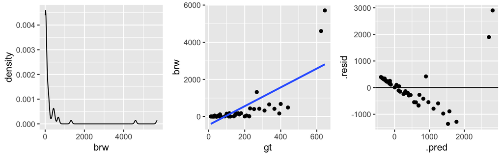

This model is **bad** – it is extremely heteroskedastic. This issue often occurs when our response variable is seriously right skewed, as `brw` is here. Luckily, logging the response variable is often an easy fix: `log_brw` = $\beta_0$ + $\beta_1$ `gt` + $\epsilon$[^1]

- Create the 3 plots above, now using `log_brw` instead of `brw`.
- Comment on how the log transformation changes the “shape” of the `brw` data.
- Comment on whether the log transformation “fixes” the model of brain weight vs gestation time.

### Part e

**CHALLENGE:** Logging our response variable changes our coefficient interpretations. For example, if $\beta_1$ is the typical change in the *logged* brain weight for every additional day of gestation, then $e^{\beta_1}$ is the *multiplicative change* in (unlogged) brain weight. Similarly, $e^{30\beta_1}$ is the *multiplicative change* in brain weight for every additional 30 days (1 month) of gestation time. For example, if $e^{30\beta_1}$ were 2, we’d say that for every extra month of gestation, brain weights tend to *double* (multiply by 2). With this in mind, interpret the $\beta_1$ coefficient from your model of `log_brw`.

## Exercise 5

**Resource reflection**

List the resources you used to complete this assignment (e.g. office hours, textbook, Gen AI, etc.)

Write 3-5 sentences about which resources were the most useful in helping you complete the assignment.

## Exercise 6

**Ethics reading and reflection**

Read the article [Amazon scraps secret AI recruiting tool that showed bias against women](https://www.reuters.com/article/us-amazon-com-jobs-automation-insight/amazon-scraps-secret-ai-recruiting-tool-that-showed-bias-against-women-idUSKCN1MK08G). Write a short (roughly 250-500 words) reaction to the article. What ideas piqued your interest? How did the article make you feel? What ideas from class did it make you think about?

## Footnotes

[^1]: By default, “log” in statistics refers to the natural log function *ln*.